# Housing Value

- Show All Code
- Hide All Code
- View Source

Author

Manu Alcalá Kovalski

Published

February 3, 2026

This program creates the **Housing Value** metric defined as the ratio between the share of a community’s housing wealth held by a racial or ethnic group to the share of households of the same group metric

Initially written by Jung Hyun Choi and updated by Manu Alcalá Kovalski in 2023-2024.

## Process

- Housekeeping
- Read Data
- Clean Data
- Merge Crosswalk
- Create Housing Value Metric
- Evaluate Results
- Export

## Housekeeping

```r
options(scipen = 999)
librarian::shelf(
  tidyverse,
  ipumsr,
  here,
  glue,
  labelled,
  skimr,
  UrbanInstitute / urbnthemes,
  tidylog,
  assertr,
  fs
)
set_urbn_defaults(style = "print")

source(here::here("functions", "testing", "evaluate_final_data.R"))
```

### Read Data

We extract the 1 year ACS files from the IPUMS API using `ipumsr`. You will need to have an API key in order to do so. If you don’t have one, you can register to the [IPUMS USA](https://uma.pop.umn.edu/usa/user/new?return_url=https%3A%2F%2Fusa.ipums.org%2Fusa-action%2Fmenu) data collection and create an API key. For more information on how to get an API key, see the `ipumsr` [getting started vignette](https://tech.popdata.org/ipumsr/articles/ipums.html).

By default, `ipumsr` API functions assume that your key is stored in the **IPUMS_API_KEY** environment variable. You can also provide your key directly to these functions, but storing it in an environment variable saves you some typing and helps prevent you from inadvertently sharing your key with others (for instance, on GitHub).

You can save your API key to the IPUMS_API_KEY environment variable with `set_ipums_api_key(api_key = "paste-your-key-here", save = TRUE)`. This will add your API key to your .Renviron file in your user home directory.

```r
## 2.1. ACS: keep households living not living in gq

# Run this the first time you run this code to avoid requesting the same data
# multiple times

acs_vars <- c(
  "YEAR", "SAMPLE", "SERIAL", "CBSERIAL", "HHWT", "CLUSTER",
  "STATEFIP", "COUNTYFIP", "MET2013", "CITY", "PUMA", "STRATA",
  "GQ", "OWNERSHP", "OWNERSHPD", "VALUEH", "PERNUM", "PERWT",
  "RACE", "RACED", "HISPAN", "HISPAND", "AGE"
)

years <- 2014:2024

if(length(fs::dir_ls(here::here("01_financial-well-being", "data"), glob = "*.xml")) == 0){

  usa_ext_def <- define_extract_usa(
  description = "ACS 1 Year 2014-2024",
  samples = paste0("us", years, "a"),
  variables = acs_vars
)

usa_ext_submitted <- submit_extract(usa_ext_def)
usa_ext_complete <- wait_for_extract(usa_ext_submitted)

# download_extract() will return a character vector including the file paths
# to all downloaded files.
# Create a data folder before running this if it doesn't exist

fs::dir_create(here("01_financial-well-being/data"))

filepath <- download_extract(usa_ext_complete,
  download_dir = here("01_financial-well-being/data")
)
}
```

### Clean data

We load the 2014-2024 1 Year ACS microdata we downloaded from IPUMS above. IPUMS loads the data as a person-level data set with some household variables. Therefore, we can analyze the data at the household level by keeping the first person sampled in the household.

**Note:** 1-yr ACS data for 2020 is not used because Census has a warning that these data [should be considered experimental](https://www.census.gov/programs-surveys/acs/technical-documentation/table-and-geography-changes/2020/1-year.html) because the quality is so unreliable and not compared to prior year

The [ipumsr](https://tech.popdata.org/ipumsr/articles/value-labels.html#remove-unused-value-labels) documentation says that:

> “labelled vectors are not intended for use throughout the entire analysis process. Instead, they should be used during the initial data preparation process to convert raw data into values that are more meaningful. These can then be converted to other variable types (often factors) for analysis. Unfortunately, this isn’t a process that can typically be automated, as it depends primarily on the research questions the data will be used to address. However, ipumsr provides several functions to manipulate value labels to make this process easier.

A useful way of finding missing value labels is to call `ipums_var_info(acs1yr)` and inspect the `val_labels`.

```r
acs1yr <-
  acs1yr_raw |>
  mutate(
    valueh = lbl_na_if(valueh, ~ .lbl %in% c("Missing", "N/A")),
  )
```

Next, we exclude individuals living in group quarters because we only want households for this metric. In particular, we exclude people living in places other than housing units (e.g., correctional facilities, nursing homes, mental hospitals, dorms, barracks, group homes, missions). For more information, see the [variable description](https://usa.ipums.org/usa-action/variables/GQ#codes_section) on IPUMS USA.

```r
acs1yr <-
  acs1yr |>
  mutate(gq = as_factor(gq)) |>
  filter(!(gq %in% c("Group quarters--Institutions", "Other group quarters")))
```

FIPS codes should always contain leading zeros so that state codes are two digits, county codes are three digits, and place codes are five digits.

```r
acs1yr <-
  acs1yr |>
  mutate(
    across(c(state, county, city, puma), as.character),
    state = str_pad(state, width = 2, pad = "0", side = "left"),
    county = str_pad(county, width = 3, pad = "0", side = "left"),
    city = str_pad(city, width = 5, pad = "0", side = "left"),
    puma = str_pad(puma, width = 5, pad = "0", side = "left")
  )
```

We create two age subgroups: households over 45 and households under 45

```r
acs1yr <-
  acs1yr |>
  mutate(subgroup = if_else(age >= 45, "Age 45 and Over", "Under Age 45"))
```

We collapse IPUMS race and ethnicity categories into white non-Hispanic, Black non-Hispanic, other non-Hispanic, and Hispanic.

```r
acs1yr <-
  acs1yr |>
  mutate(
    race = lbl_relabel(race, lbl(10, "Other") ~ .lbl %in% c("American Indian or Alaska Native", "Chinese", "Japanese", "Other Asian or Pacific Islander", "Other race, nec", "Two major races", "Three or more major races")),
    across(c(race, hispan), as_factor)
  ) |>
  mutate(
    race_ethnicity = case_when(
      race == "White" & hispan == "Not Hispanic" ~ "white_nh",
      race == "Black/African American" & hispan == "Not Hispanic" ~ "black_nh",
      race == "Other" & hispan == "Not Hispanic" ~ "other_nh",
      hispan != "Not Hispanic" ~ "hispanic",
      .default = NA_character_
    ),
    race_ethnicity = factor(race_ethnicity,
      levels = c(
        "white_nh",
        "black_nh",
        "hispanic",
        "other_nh"
      )
    )
  )
```

## Merge Crosswalk

We merge our 1-year ACS data with PUMA-county and PUMA-place geocodes to get county and place boundaries.

For 2022 ACS and onward we use a crosswalk going from 2020 PUMA to 2020 county. For pre-2022 ACS data, we use a crosswalk from 2012 PUMA to 2016 county.

The weight of each household is adjusted by the area of the PUMA that falls into a given County/Place.

Connecticut counties should be present in the data before 2022 and planning regions *only* after 2022.

```r
acs1yr <-
  acs1yr |>
  mutate(crosswalk_period = if_else(year < 2022, "pre-2022", "2022"))

# Check that only new planning regions are present after 2022 for CT
assertthat::assert_that(
  setequal(
    acs1yr |>
      select(year, state, county) |>
      filter(state == "09", year %in% c(2022, 2023, 2024)) |>
      distinct(county) |>
      pull(),
    c("170", "000", "190", "140", "180", "130", "120", "160")
  )
)
```

```
[1] TRUE
```

```r
county_file <- read_csv(here::here("geographic-crosswalks", "data", "county-populations.csv"))

county_file |>
  filter(year == 2021, state == "09")
```

```
# A tibble: 8 × 6
   year state county state_name  county_name       population
  <dbl> <chr> <chr>  <chr>       <chr>                  <dbl>
1  2021 09    001    Connecticut Fairfield County      959768
2  2021 09    003    Connecticut Hartford County       896854
3  2021 09    005    Connecticut Litchfield County     185000
4  2021 09    007    Connecticut Middlesex County      164759
5  2021 09    009    Connecticut New Haven County      863700
6  2021 09    011    Connecticut New London County     268805
7  2021 09    013    Connecticut Tolland County        150293
8  2021 09    015    Connecticut Windham County        116418
```

**County**

To assess the data quality of counties/places with larger N, we need to consider what percent of data for the county/place actually came from the county/place itself. We have this information in the `sum_products` column obtained from the crosswalk file. For more information on `sum_products` see the script that generates the PUMA to County crosswalk

```r
puma_county_crosswalk <-
  read_csv(here::here(
    "geographic-crosswalks",
    "data",
    "crosswalk_puma_to_county.csv"
  )) |>
  rename(
    state = statefip,
  ) |>
  # Filter out Puerto Rico since this will be NA for the ACS data
  filter(state != "72")


households_county <-
  acs1yr |>
  right_join(puma_county_crosswalk,
    by = c("state", "puma", "crosswalk_period")
  ) |>

  mutate(
    # if county isn't present in the ACS use county codes from PUMA-County crosswalk
    county = if_else(county.x != "000", county.x, county.y),
    # the weight of each household is adjusted by the area of the PUMA that falls into a given County
    hhwt = if_else(county.x != "000", hhwt, hhwt * afact),
    sum_products = if_else(county.x != "000", 1, sum_products)
  ) |>
  select(-c(county.x, county.y)) |>
  # Remove old counties from 2022 Connecticut data, but keep county "000"
  filter(!(year == 2022 & state == "09" & str_starts(county, "0") & county != "000"))
  puma_county_crosswalk |>
  filter(state == "09", crosswalk_period == "2022") |>
  distinct(county)
```

```
# A tibble: 9 × 1
  county
  <chr>
1 110
2 120
3 130
4 140
5 150
6 160
7 170
8 180
9 190
```

**Place**

```r
puma_place_crosswalk <-
  read_csv(here::here(
    "geographic-crosswalks",
    "data",
    "crosswalk_puma_to_place.csv"
  )) |>
  rename(state = statefip)

households_place <-
  acs1yr |>
  right_join(puma_place_crosswalk,
    by = c("state", "puma", "crosswalk_period")
  ) |>
  # there aren't any places missing from the ACS so we just adjust household
  # weight to account for PUMA-to-place mapping (those where the PUMA is not entirely inside the place)
  mutate(hhwt = hhwt * afact)
```

## Create Housing Value Metric

### Housing Share

We will now compute the share of households by race and ethnicity (i.e., total number of households for each race and ethnic group divided by the total number of households). In other words, for each race and ethnicity, we compute the share of total households in a county/place by dividing the total number of households of that race and ethnicity by the total number of households in the county/place.

Further, for each race-ethnicity and subgroup (e.g., age), we compute the share of total households in that subgroup by dividing the total number of households of that race-ethnicity and subgroup by the total number of households in that subgroup in the county/place.

**County**

```r
share_households_county <-
  households_county |>
  select(year, state, county, hhwt, race_ethnicity) |>
  summarise(
    household = sum(hhwt),
    .by = c(year, state, county, race_ethnicity)
  ) |>
  mutate(
    total = sum(household),
    .by = c(year, state, county)
  ) |>
  mutate(share_households = household / total) |>
  select(year, state, county, race_ethnicity, share_households)

share_households_county_subgroup <-
  households_county |>
  select(year, state, county, hhwt, race_ethnicity, subgroup) |>
  summarise(
    household = sum(hhwt),
    .by = c(year, state, county, race_ethnicity, subgroup)
  ) |>
  mutate(
    total = sum(household),
    .by = c(year, state, county, subgroup)
  ) |>
  mutate(share_households = household / total) |>
  select(year, state, county, race_ethnicity, subgroup, share_households)
```

**Check:** Is `share_households` between 0 and 1?

```r
stopifnot(min(share_households_county$share_households) >= 0)
stopifnot(max(share_households_county$share_households) <= 1)
```

We visualize the distribution of the share of households by race and ethnicity

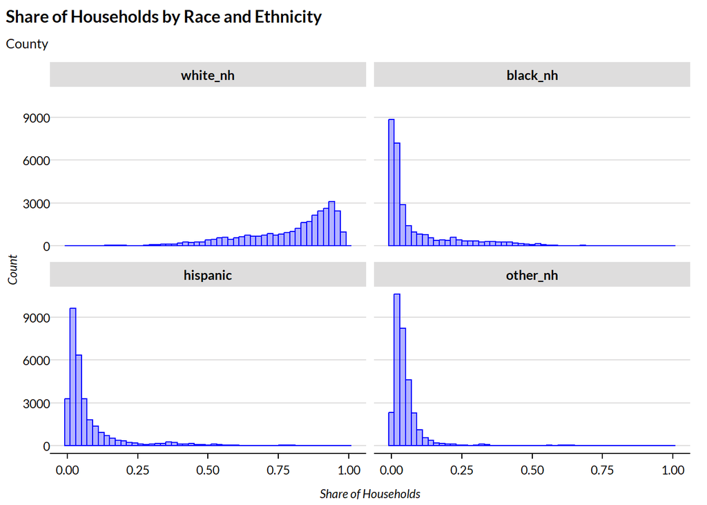

```r
share_households_county |>
  drop_na() |>
  ggplot(aes(x = share_households)) +
  geom_histogram(color = "blue", fill = alpha("blue", 0.3), binwidth = 0.02) +
  facet_wrap(. ~ race_ethnicity) +
  labs(
    title = "Share of Households by Race and Ethnicity",
    subtitle = "County",
    y = "Count",
    x = "Share of Households"
  )
```

```r
summary(share_households_county)
```

```
      year         state              county           race_ethnicity
 Min.   :2014   Length:123753      Length:123753      white_nh:31433
 1st Qu.:2016   Class :character   Class :character   black_nh:29558
 Median :2019   Mode  :character   Mode  :character   hispanic:31347
 Mean   :2019                                         other_nh:31415
 3rd Qu.:2022
 Max.   :2024
 share_households
 Min.   :0.0000247
 1st Qu.:0.0209153
 Median :0.0545039
 Mean   :0.2539979
 3rd Qu.:0.4799736
 Max.   :0.9927929
```

```r
skimr::skim(share_households_county)
```

Data summary

| Name | share_households_county |
| --- | --- |
| Number of rows | 123753 |
| Number of columns | 5 |
| _______________________ |  |
| Column type frequency: |  |
| character | 2 |
| factor | 1 |
| numeric | 2 |
| ________________________ |  |
| Group variables | None |

**Variable type: character**

| skim_variable | n_missing | complete_rate | min | max | empty | n_unique | whitespace |
| --- | --- | --- | --- | --- | --- | --- | --- |
| state | 0 | 1 | 2 | 2 | 0 | 51 | 0 |
| county | 0 | 1 | 3 | 3 | 0 | 329 | 0 |

**Variable type: factor**

| skim_variable | n_missing | complete_rate | ordered | n_unique | top_counts |
| --- | --- | --- | --- | --- | --- |
| race_ethnicity | 0 | 1 | FALSE | 4 | whi: 31433, oth: 31415, his: 31347, bla: 29558 |

**Variable type: numeric**

| skim_variable | n_missing | complete_rate | mean | sd | p0 | p25 | p50 | p75 | p100 | hist |
| --- | --- | --- | --- | --- | --- | --- | --- | --- | --- | --- |
| year | 0 | 1 | 2018.90 | 3.30 | 2014 | 2016.00 | 2019.00 | 2022.00 | 2024.00 | ▇▆▃▆▆ |
| share_households | 0 | 1 | 0.25 | 0.34 | 0 | 0.02 | 0.05 | 0.48 | 0.99 | ▇▁▁▁▂ |

```r
stopifnot(min(share_households_county_subgroup$share_households) >= 0)
stopifnot(max(share_households_county_subgroup$share_households) <= 1)
```

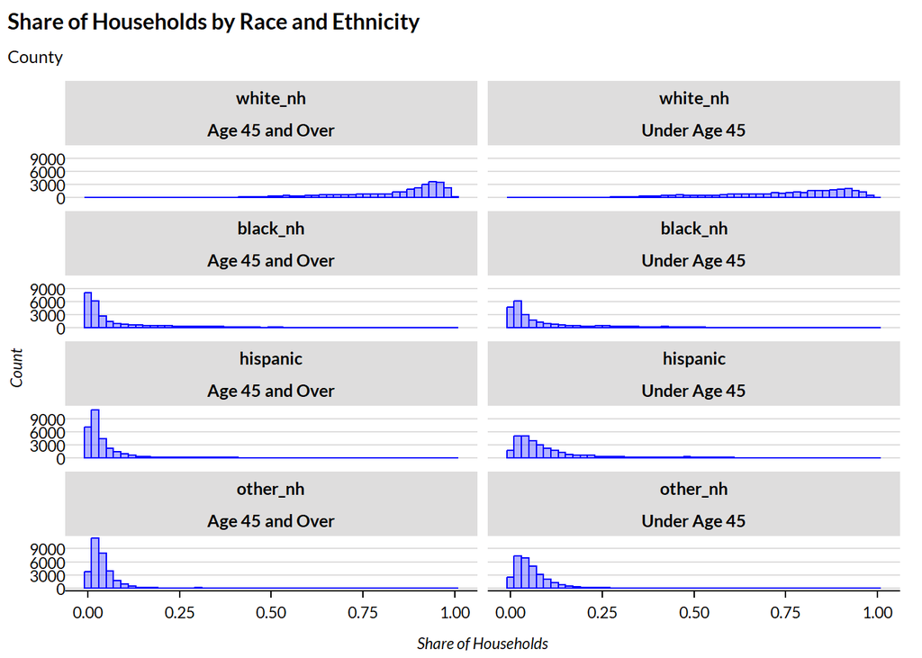

```r
share_households_county_subgroup |>
  ggplot(aes(x = share_households)) +
  geom_histogram(color = "blue", fill = alpha("blue", 0.3), binwidth = 0.02) +
  facet_wrap(race_ethnicity ~ subgroup, ncol = 2) +
  labs(
    title = "Share of Households by Race and Ethnicity",
    subtitle = "County",
    y = "Count",
    x = "Share of Households"
  )
```

```r
summary(share_households_county_subgroup)
```

```
      year         state              county           race_ethnicity
 Min.   :2014   Length:239536      Length:239536      white_nh:62866
 1st Qu.:2016   Class :character   Class :character   black_nh:52898
 Median :2019   Mode  :character   Mode  :character   hispanic:61636
 Mean   :2019                                         other_nh:62136
 3rd Qu.:2022
 Max.   :2024
   subgroup         share_households
 Length:239536      Min.   :0.0000186
 Class :character   1st Qu.:0.0224124
 Mode  :character   Median :0.0653013
                    Mean   :0.2624491
                    3rd Qu.:0.4971958
                    Max.   :1.0000000
```

```r
skimr::skim(share_households_county_subgroup)
```

Data summary

| Name | share_households_county_s… |
| --- | --- |
| Number of rows | 239536 |
| Number of columns | 6 |
| _______________________ |  |
| Column type frequency: |  |
| character | 3 |
| factor | 1 |
| numeric | 2 |
| ________________________ |  |
| Group variables | None |

**Variable type: character**

| skim_variable | n_missing | complete_rate | min | max | empty | n_unique | whitespace |
| --- | --- | --- | --- | --- | --- | --- | --- |
| state | 0 | 1 | 2 | 2 | 0 | 51 | 0 |
| county | 0 | 1 | 3 | 3 | 0 | 329 | 0 |
| subgroup | 0 | 1 | 12 | 15 | 0 | 2 | 0 |

**Variable type: factor**

| skim_variable | n_missing | complete_rate | ordered | n_unique | top_counts |
| --- | --- | --- | --- | --- | --- |
| race_ethnicity | 0 | 1 | FALSE | 4 | whi: 62866, oth: 62136, his: 61636, bla: 52898 |

**Variable type: numeric**

| skim_variable | n_missing | complete_rate | mean | sd | p0 | p25 | p50 | p75 | p100 | hist |
| --- | --- | --- | --- | --- | --- | --- | --- | --- | --- | --- |
| year | 0 | 1 | 2018.92 | 3.30 | 2014 | 2016.00 | 2019.00 | 2022.0 | 2024 | ▇▆▃▆▆ |
| share_households | 0 | 1 | 0.26 | 0.33 | 0 | 0.02 | 0.07 | 0.5 | 1 | ▇▁▁▁▂ |

**Place**

```r
share_households_place <-
  households_place |>
  select(year, state, place, hhwt, race_ethnicity) |>
  summarise(
    households = sum(hhwt),
    .by = c(year, state, place, race_ethnicity)
  ) |>
  mutate(
    total_households = sum(households),
    .by = c(year, state, place)
  ) |>
  mutate(share_households = households / total_households) |>
  select(year, state, place, race_ethnicity, share_households)

share_households_place_subgroup <-
  households_place |>
  select(year, state, place, hhwt, race_ethnicity, subgroup) |>
  summarise(
    households = sum(hhwt),
    .by = c(year, state, place, race_ethnicity, subgroup)
  ) |>
  mutate(
    total_households = sum(households),
    .by = c(year, state, place, subgroup)
  ) |>
  mutate(share_households = households / total_households) |>
  select(year, state, place, race_ethnicity, subgroup, share_households)
```

**Check:** Is `share_households` between 0 and 1?

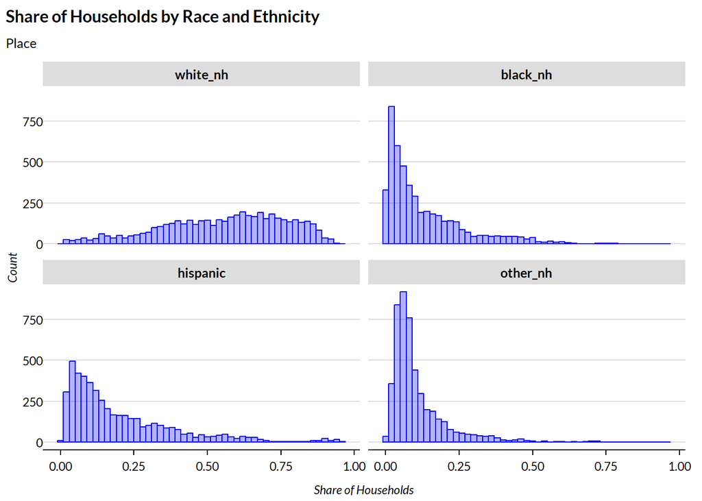

```r
stopifnot(min(share_households_place$share_households) >= 0)
stopifnot(max(share_households_place$share_households) <= 1)

share_households_place |>
  ggplot(aes(x = share_households)) +
  geom_histogram(color = "blue", fill = alpha("blue", 0.3), binwidth = 0.02) +
  facet_wrap(. ~ race_ethnicity) +
  labs(
    title = "Share of Households by Race and Ethnicity",
    subtitle = "Place",
    y = "Count",
    x = "Share of Households"
  )
```

```r
skimr::skim(share_households_place)
```

Data summary

| Name | share_households_place |
| --- | --- |
| Number of rows | 19383 |
| Number of columns | 5 |
| _______________________ |  |
| Column type frequency: |  |
| character | 2 |
| factor | 1 |
| numeric | 2 |
| ________________________ |  |
| Group variables | None |

**Variable type: character**

| skim_variable | n_missing | complete_rate | min | max | empty | n_unique | whitespace |
| --- | --- | --- | --- | --- | --- | --- | --- |
| state | 0 | 1 | 2 | 2 | 0 | 46 | 0 |
| place | 0 | 1 | 5 | 5 | 0 | 386 | 0 |

**Variable type: factor**

| skim_variable | n_missing | complete_rate | ordered | n_unique | top_counts |
| --- | --- | --- | --- | --- | --- |
| race_ethnicity | 0 | 1 | FALSE | 4 | whi: 4853, his: 4853, oth: 4852, bla: 4825 |

**Variable type: numeric**

| skim_variable | n_missing | complete_rate | mean | sd | p0 | p25 | p50 | p75 | p100 | hist |
| --- | --- | --- | --- | --- | --- | --- | --- | --- | --- | --- |
| year | 0 | 1 | 2018.90 | 3.30 | 2014 | 2016.00 | 2019.00 | 2022.0 | 2024.00 | ▇▆▃▆▆ |
| share_households | 0 | 1 | 0.25 | 0.24 | 0 | 0.06 | 0.14 | 0.4 | 0.97 | ▇▂▂▂▁ |

```r
summary(share_households_place)
```

```
      year         state              place            race_ethnicity
 Min.   :2014   Length:19383       Length:19383       white_nh:4853
 1st Qu.:2016   Class :character   Class :character   black_nh:4825
 Median :2019   Mode  :character   Mode  :character   hispanic:4853
 Mean   :2019                                         other_nh:4852
 3rd Qu.:2022
 Max.   :2024
 share_households
 Min.   :0.000046
 1st Qu.:0.060381
 Median :0.142552
 Mean   :0.250374
 3rd Qu.:0.397147
 Max.   :0.966877
```

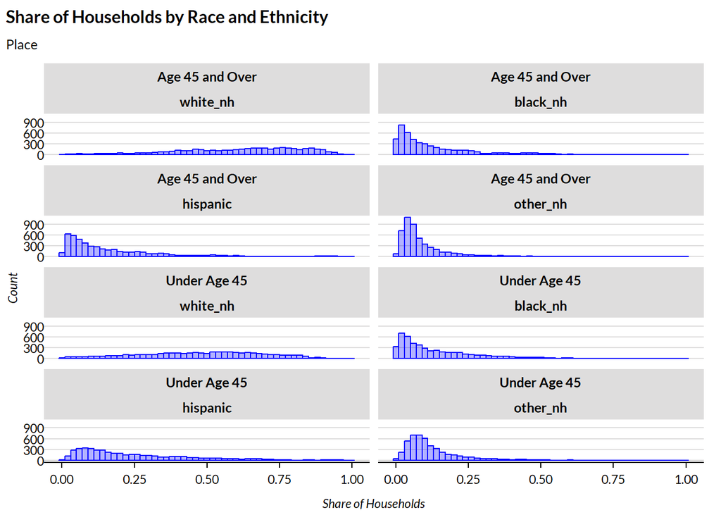

```r
stopifnot(min(share_households_place_subgroup$share_households) >= 0)
stopifnot(max(share_households_place_subgroup$share_households) <= 1)

share_households_place_subgroup |>
  ggplot(aes(x = share_households)) +
  geom_histogram(color = "blue", fill = alpha("blue", 0.3), binwidth = 0.02) +
  facet_wrap(subgroup ~ race_ethnicity, ncol = 2) +
  labs(
    title = "Share of Households by Race and Ethnicity",
    subtitle = "Place",
    y = "Count",
    x = "Share of Households"
  )
```

```r
skimr::skim(share_households_place_subgroup)
```

Data summary

| Name | share_households_place_su… |
| --- | --- |
| Number of rows | 38634 |
| Number of columns | 6 |
| _______________________ |  |
| Column type frequency: |  |
| character | 3 |
| factor | 1 |
| numeric | 2 |
| ________________________ |  |
| Group variables | None |

**Variable type: character**

| skim_variable | n_missing | complete_rate | min | max | empty | n_unique | whitespace |
| --- | --- | --- | --- | --- | --- | --- | --- |
| state | 0 | 1 | 2 | 2 | 0 | 46 | 0 |
| place | 0 | 1 | 5 | 5 | 0 | 386 | 0 |
| subgroup | 0 | 1 | 12 | 15 | 0 | 2 | 0 |

**Variable type: factor**

| skim_variable | n_missing | complete_rate | ordered | n_unique | top_counts |
| --- | --- | --- | --- | --- | --- |
| race_ethnicity | 0 | 1 | FALSE | 4 | whi: 9703, his: 9699, oth: 9695, bla: 9537 |

**Variable type: numeric**

| skim_variable | n_missing | complete_rate | mean | sd | p0 | p25 | p50 | p75 | p100 | hist |
| --- | --- | --- | --- | --- | --- | --- | --- | --- | --- | --- |
| year | 0 | 1 | 2018.91 | 3.30 | 2014 | 2016.00 | 2019.00 | 2022.0 | 2024 | ▇▆▃▆▆ |
| share_households | 0 | 1 | 0.25 | 0.24 | 0 | 0.06 | 0.15 | 0.4 | 1 | ▇▂▂▁▁ |

```r
summary(share_households_place_subgroup)
```

```
      year         state              place            race_ethnicity
 Min.   :2014   Length:38634       Length:38634       white_nh:9703
 1st Qu.:2016   Class :character   Class :character   black_nh:9537
 Median :2019   Mode  :character   Mode  :character   hispanic:9699
 Mean   :2019                                         other_nh:9695
 3rd Qu.:2022
 Max.   :2024
   subgroup         share_households
 Length:38634       Min.   :0.0000005
 Class :character   1st Qu.:0.0594909
 Mode  :character   Median :0.1468884
                    Mean   :0.2512295
                    3rd Qu.:0.3973741
                    Max.   :1.0000000
```

### Housing Value Share

We keep observations for homeowners only in order to calculate the housing value share. I.e., the total aggregated housing wealth for homeowners for each race and ethnic group divided by the total aggregated housing value.

```r
house_value_by_race <- function(data, ...) {
  data |>
    mutate(ownership = as_factor(ownership)) |>
    filter(ownership == "Owned or being bought (loan)") |>
    summarise(
      house_value = sum(valueh * hhwt),
      home_owners = n(),
      .by = c(year, state, race_ethnicity, ...)
    )
}

house_value_county_subgroup <- house_value_by_race(households_county, county, subgroup)
house_value_county <- house_value_by_race(households_county, county)


house_value_place_subgroup <- house_value_by_race(households_place, place, subgroup)
house_value_place <- house_value_by_race(households_place, place)
```

### Data Quality Flags

The metrics for the ACS indices are based on:

- 1. sample size of each race and ethnic household at the county/place and
- 2. the number of observations that comes from the specific county/place calculated from the PUMA-county/place crosswalk.

Therefore, the data quality is poor for counties/places with a extremely small number of households (N). To assess the data quality of counties/places with larger N, we need to consider what percent of data for the county/place actually came from the county/place itself. We have this information in the `sum_products` column obtained from the crosswalk file. To read more about how it was constructed, see the “Create quality variable” section of the “Generate Puma to County Crosswalk” notebook.

In particular,

- Data quality is good (`1`): N is greater than 30 and more than 75% of observations are from the county/place.
- Data quality is marginal (`2`): N is greater than 30 but more than 35% but less than 75% or equal of observations are from the county/place.
- Data quality is poor (`3`): If less than or equal 35% of observations are from the county/place
- Data quality is NA if N is less than or equal to 30.

```r
construct_quality_flag <- function(x, y) {
  case_when(
    x > 30 & y > 0.75 ~ 1,
    x > 30 & (y > 0.35 & y <= 0.75) ~ 2,
    x > 30 & y <= 0.35 ~ 3,
    x <= 30 ~ NA_integer_,
    .default = NA_integer_
  )
}
```

Now, we implement the data quality flags explained above

**County**

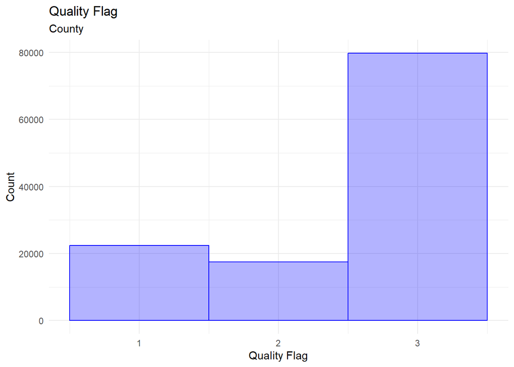

```r
county_quality <-
  households_county |>
  distinct(year, state, county, .keep_all = TRUE) |>
  select(year, state, county, population, sum_products, geographic_allocation_quality)


house_value_county <-
  house_value_county |>
  left_join(county_quality, by = c("year", "state", "county")) |>
  mutate(
    ratio_house_value_households_quality = construct_quality_flag(population, sum_products)
  )

house_value_county |>
  ggplot(aes(x = ratio_house_value_households_quality)) +
  geom_histogram(color = "blue", fill = alpha("blue", 0.3), binwidth = 1.0) +
  theme_minimal() +
  labs(
    title = "Quality Flag",
    subtitle = "County",
    x = "Quality Flag",
    y = "Count"
  )
```

```r
janitor::tabyl(house_value_county, ratio_house_value_households_quality)
```

```
 ratio_house_value_households_quality     n   percent
                                    1 22432 0.1875287
                                    2 17471 0.1460554
                                    3 79716 0.6664159
```

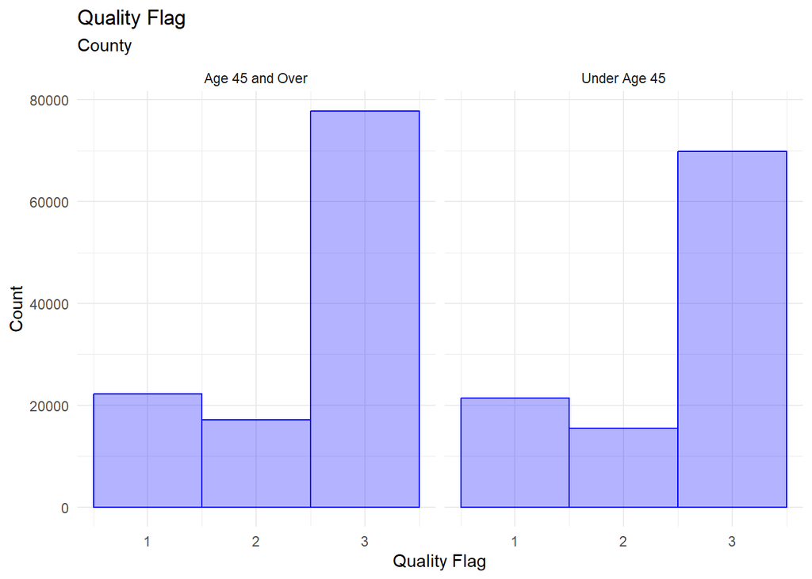

```r
house_value_county_subgroup <-
  house_value_county_subgroup |>
  left_join(county_quality, by = c("year", "state", "county")) |>
  mutate(
    ratio_house_value_households_quality = construct_quality_flag(population, sum_products)
  )

house_value_county_subgroup |>
  ggplot(aes(x = ratio_house_value_households_quality)) +
  geom_histogram(color = "blue", fill = alpha("blue", 0.3), binwidth = 1.0) +
  theme_minimal() +
  labs(
    title = "Quality Flag",
    subtitle = "County",
    x = "Quality Flag",
    y = "Count"
  ) +
  facet_wrap(. ~ subgroup, ncol = 2)
```

**Place**

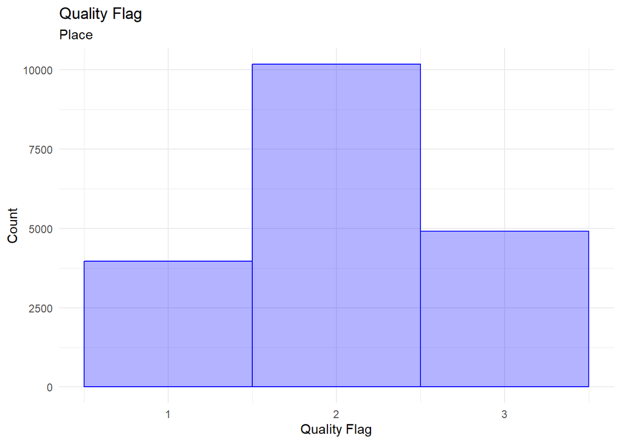

```r
place_quality <-
  households_place %>%
  distinct(state, place, .keep_all = TRUE) |>
  select(state, place, sum_products, population)

house_value_place <-
  house_value_place |>
  left_join(place_quality,
    by = c("state", "place")
  ) |>
  mutate(
    ratio_house_value_households_quality = construct_quality_flag(population, sum_products)
  )


house_value_place |>
  ggplot(aes(x = ratio_house_value_households_quality)) +
  geom_histogram(color = "blue", fill = alpha("blue", 0.3), binwidth = 1.0) +
  theme_minimal() +
  labs(
    title = "Quality Flag",
    subtitle = "Place",
    x = "Quality Flag",
    y = "Count"
  )
```

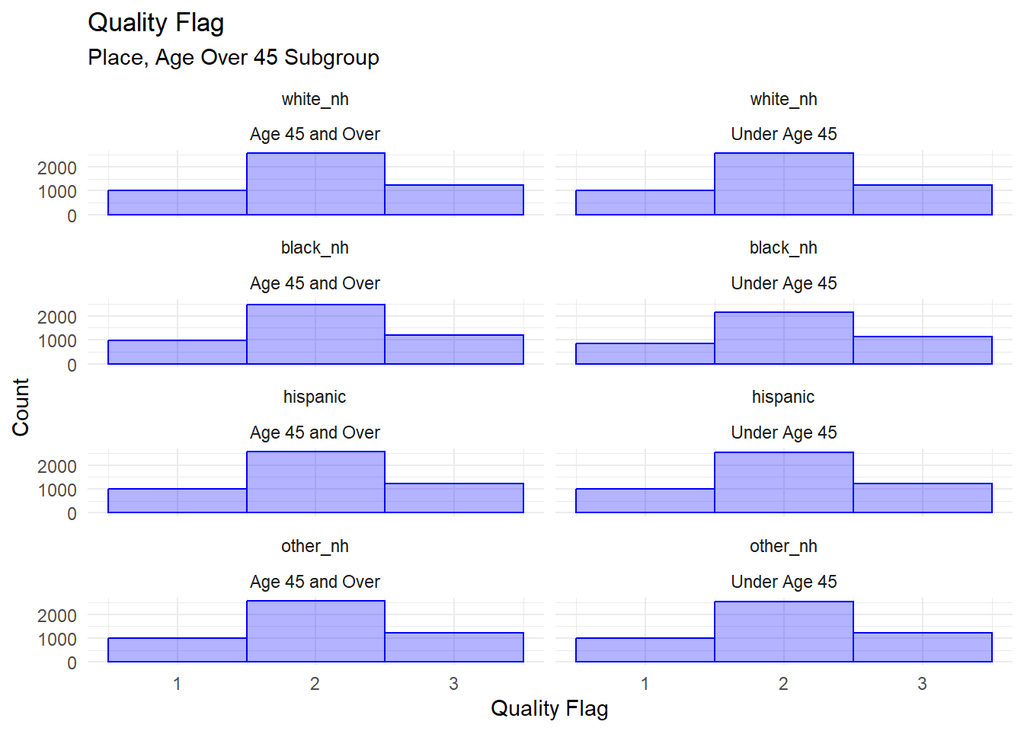

```r
house_value_place_subgroup <-
  house_value_place_subgroup |>
  left_join(place_quality,
    by = c("state", "place")
  ) |>
  mutate(
    ratio_house_value_households_quality = construct_quality_flag(population, sum_products)
  )


house_value_place_subgroup |>
  ggplot(aes(x = ratio_house_value_households_quality)) +
  geom_histogram(color = "blue", fill = alpha("blue", 0.3), binwidth = 1.0) +
  theme_minimal() +
  labs(
    title = "Quality Flag",
    subtitle = "Place, Age Over 45 Subgroup",
    x = "Quality Flag",
    y = "Count"
  ) +
  facet_wrap(race_ethnicity ~ subgroup, ncol = 2)
```

Now, we calculate the housing value share by computing house value divided by the aggregate house value for a county/place.

```r
house_value_by_race <- function(data, ...) {
  data |>
    mutate(total_house_value = sum(house_value), .by = c(year, state, ...)) |>
    mutate(share_house_value = house_value / total_house_value) |>
    select(year, state, ..., race_ethnicity, house_value, total_house_value, share_house_value, ratio_house_value_households_quality)
}



house_value_county <- house_value_by_race(house_value_county, county)
house_value_county_subgroup <- house_value_by_race(house_value_county_subgroup, county, subgroup)
house_value_place <- house_value_by_race(house_value_place, place)
house_value_place_subgroup <- house_value_by_race(house_value_place_subgroup, place, subgroup)
```

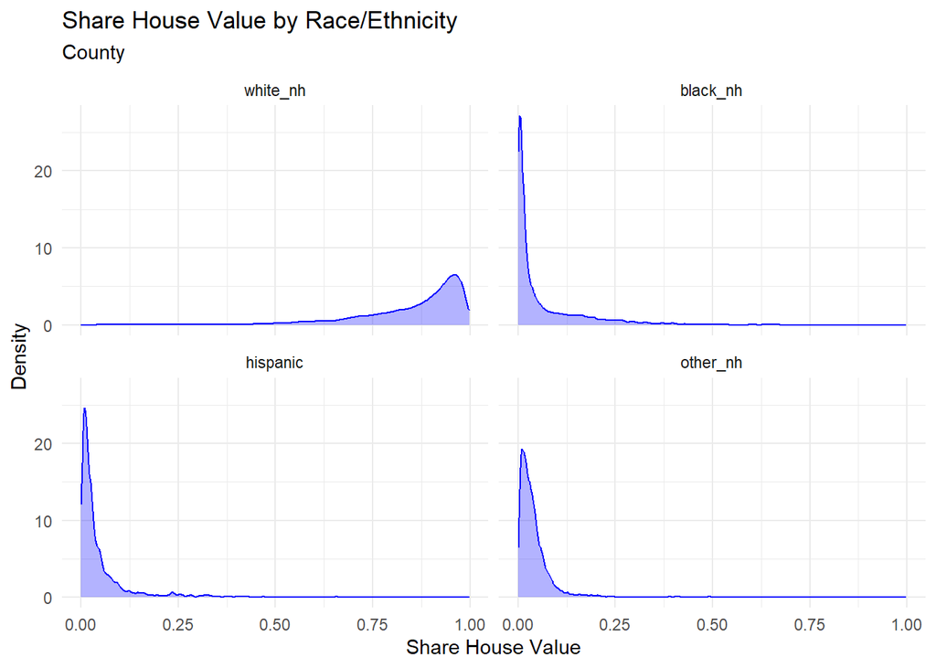

```r
house_value_county |>
  ggplot() +
  geom_density(aes(x = share_house_value),
    color = "blue", fill = alpha("blue", 0.3)
  ) +
  facet_wrap(. ~ race_ethnicity) +
  theme_minimal() +
  labs(
    title = "Share House Value by Race/Ethnicity",
    subtitle = "County",
    x = "Share House Value",
    y = "Density"
  )
```

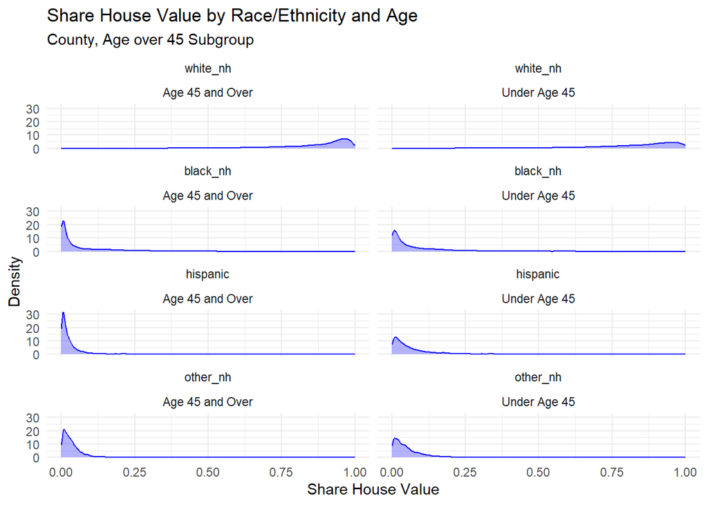

```r
house_value_county_subgroup |>
  ggplot() +
  geom_density(aes(x = share_house_value),
    color = "blue", fill = alpha("blue", 0.3)
  ) +
  facet_wrap(race_ethnicity ~ subgroup, ncol = 2) +
  theme_minimal() +
  labs(
    title = "Share House Value by Race/Ethnicity and Age",
    subtitle = "County, Age over 45 Subgroup",
    x = "Share House Value",
    y = "Density"
  )
```

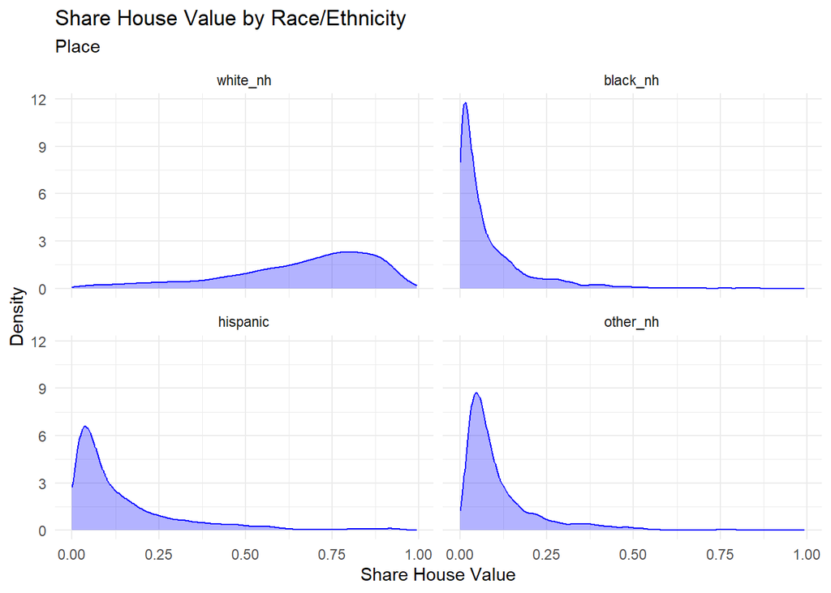

```r
house_value_place |>
  ggplot() +
  geom_density(aes(x = share_house_value),
    color = "blue", fill = alpha("blue", 0.3)
  ) +
  facet_wrap(. ~ race_ethnicity) +
  theme_minimal() +
  labs(
    title = "Share House Value by Race/Ethnicity",
    subtitle = "Place",
    x = "Share House Value",
    y = "Density"
  )
```

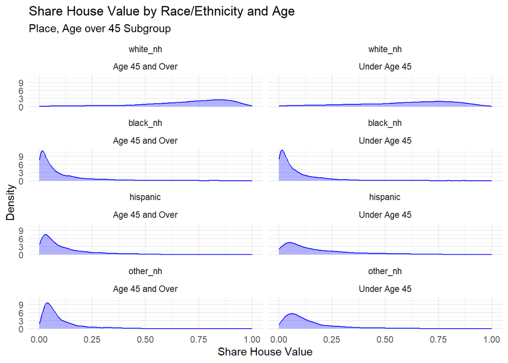

```r
house_value_place_subgroup |>
  ggplot() +
  geom_density(aes(x = share_house_value),
    color = "blue", fill = alpha("blue", 0.3)
  ) +
  facet_wrap(race_ethnicity ~ subgroup, ncol = 2) +
  theme_minimal() +
  labs(
    title = "Share House Value by Race/Ethnicity and Age",
    subtitle = "Place, Age over 45 Subgroup",
    x = "Share House Value",
    y = "Density"
  )
```

## Create Final Output Data: Merge Household & Housing Value Share

```r
construct_ratio <- function(share_house_value, share_households) {
  paste0(
    format(round(share_house_value, 3), nsmall = 1),
    ":",
    format(round(share_households, 3), nsmall = 1)
  ) |>
    str_remove_all(pattern = " ")
}

ratio_house_value_households <- function(households_data, house_value_data, ...) {
  geo_var <- if_else("county" %in% colnames(households_data), "county", "place")
  households_data |>
    left_join(house_value_data,
      by = c("year", "state", geo_var, "race_ethnicity", ...)
    ) |>
    mutate(
      ratio_house_value_households = construct_ratio(share_house_value, share_households),
      .by = c(race_ethnicity, ...)
    ) |>
    arrange(year, state, {{ geo_var }}, ...) |>
    mutate(ratio_house_value_households = if_else(is.na(ratio_house_value_households_quality), NA_character_, ratio_house_value_households))
}


reshape_to_wide <- function(data, ...) {
  data |>
    pivot_wider(
      id_cols = c(year, state, ...),
      names_from = race_ethnicity,
      values_from = c(ratio_house_value_households, ratio_house_value_households_quality),
      names_glue = "{race_ethnicity}_{.value}"
    ) %>%
    rename_with(~ str_remove(.x, "ratio_") %>% paste0("ratio_", .), contains("ratio")) %>%
    # order variables according to request
    select(
      year, state, ...,
      ratio_black_nh_house_value_households, ratio_black_nh_house_value_households_quality,
      ratio_hispanic_house_value_households, ratio_hispanic_house_value_households_quality,
      ratio_other_nh_house_value_households, ratio_other_nh_house_value_households_quality,
      ratio_white_nh_house_value_households, ratio_white_nh_house_value_households_quality
    ) %>%
    arrange(year, state, ...)
}
```

Before computing the ratio of house value to households, we need to merge the household and house value data. We do not expect perfect matches between the two datasets because the house value data is based on households that own their homes, while the household data includes all households.

```r
ratio_house_value_households_county <- ratio_house_value_households(
  share_households_county,
  house_value_county
) |>
  reshape_to_wide(county)


ratio_house_value_households_county_subgroup <- ratio_house_value_households(
  share_households_county_subgroup,
  house_value_county_subgroup,
  "subgroup"
) |>
  reshape_to_wide(county, subgroup)

ratio_house_value_households_place <-
  ratio_house_value_households(
    share_households_place,
    house_value_place
  ) |>
  reshape_to_wide(place)

ratio_house_value_households_place_subgroup <-
  ratio_house_value_households(
    share_households_place_subgroup,
    house_value_place_subgroup,
    "subgroup"
  ) |>
  reshape_to_wide(place, subgroup)
```

**Check:** Are there 3,143 counties and 486 places in the final output?

```r
stopifnot(
  ratio_house_value_households_county |>
    distinct(year, state, county) |>
    count(year) |>
    filter(!(year %in% c(2022, 2023, 2024))) |>
    pull(n) == 3143
)


stopifnot(
  ratio_house_value_households_place |>
    distinct(year, state, place) |>
    count(year) |>
    filter(year %in% c(2022, 2023, 2024)) |>
    pull(n) == 486
)
```

```r
all_counties <- read_csv(here::here("geographic-crosswalks", "data", "county-populations.csv")) %>%
  tidylog::filter(year %in% c(2022, 2023, 2024)) %>%
  select(-year)

(
  missing_counties <- ratio_house_value_households_county %>%
    filter(year %in% c(2022, 2023, 2024)) |>
    distinct(state, county) |>
    anti_join(x = all_counties, y = _, by = c("state", "county"))
)
```

```
# A tibble: 0 × 5
# ℹ 5 variables: state <chr>, county <chr>, state_name <chr>,
#   county_name <chr>, population <dbl>
```

```r
all_counties |>
  filter(state == "09")
```

```
# A tibble: 27 × 5
   state county state_name  county_name                               population
   <chr> <chr>  <chr>       <chr>                                          <dbl>
 1 09    110    Connecticut Capitol Planning Region                       981447
 2 09    120    Connecticut Greater Bridgeport Planning Region            327286
 3 09    130    Connecticut Lower Connecticut River Valley Planning …     176622
 4 09    140    Connecticut Naugatuck Valley Planning Region              454083
 5 09    150    Connecticut Northeastern Connecticut Planning Region       96196
 6 09    160    Connecticut Northwest Hills Planning Region               113234
 7 09    170    Connecticut South Central Connecticut Planning Region     573244
 8 09    180    Connecticut Southeastern Connecticut Planning Region      280403
 9 09    190    Connecticut Western Connecticut Planning Region           623690
10 09    110    Connecticut Capitol Planning Region                       975328
# ℹ 17 more rows
```

```r
stopifnot(
  ratio_house_value_households_county |>
    distinct(year, state, county) |>
    count(year) |>
    filter(year >= 2022) |>
    pull(n) |> unique() == 3144
)
```

Check number of missings and variable summaries before exporting:

```r
skimr::skim(ratio_house_value_households_county)
```

Data summary

| Name | ratio_house_value_househo… |
| --- | --- |
| Number of rows | 31433 |
| Number of columns | 11 |
| _______________________ |  |
| Column type frequency: |  |
| character | 6 |
| numeric | 5 |
| ________________________ |  |
| Group variables | None |

**Variable type: character**

| skim_variable | n_missing | complete_rate | min | max | empty | n_unique | whitespace |
| --- | --- | --- | --- | --- | --- | --- | --- |
| state | 0 | 1.00 | 2 | 2 | 0 | 51 | 0 |
| county | 0 | 1.00 | 3 | 3 | 0 | 329 | 0 |
| ratio_black_nh_house_value_households | 5577 | 0.82 | 11 | 11 | 0 | 5872 | 0 |
| ratio_hispanic_house_value_households | 459 | 0.99 | 11 | 11 | 0 | 5773 | 0 |
| ratio_other_nh_house_value_households | 77 | 1.00 | 11 | 11 | 0 | 5047 | 0 |
| ratio_white_nh_house_value_households | 0 | 1.00 | 11 | 11 | 0 | 9924 | 0 |

**Variable type: numeric**

| skim_variable | n_missing | complete_rate | mean | sd | p0 | p25 | p50 | p75 | p100 | hist |
| --- | --- | --- | --- | --- | --- | --- | --- | --- | --- | --- |
| year | 0 | 1.00 | 2018.90 | 3.30 | 2014 | 2016 | 2019 | 2022 | 2024 | ▇▅▂▆▆ |
| ratio_black_nh_house_value_households_quality | 5577 | 0.82 | 2.43 | 0.82 | 1 | 2 | 3 | 3 | 3 | ▂▁▂▁▇ |
| ratio_hispanic_house_value_households_quality | 459 | 0.99 | 2.49 | 0.78 | 1 | 2 | 3 | 3 | 3 | ▂▁▂▁▇ |
| ratio_other_nh_house_value_households_quality | 77 | 1.00 | 2.49 | 0.78 | 1 | 2 | 3 | 3 | 3 | ▂▁▂▁▇ |
| ratio_white_nh_house_value_households_quality | 0 | 1.00 | 2.50 | 0.78 | 1 | 2 | 3 | 3 | 3 | ▂▁▂▁▇ |

```r
skimr::skim(ratio_house_value_households_county_subgroup)
```

Data summary

| Name | ratio_house_value_househo… |
| --- | --- |
| Number of rows | 62866 |
| Number of columns | 12 |
| _______________________ |  |
| Column type frequency: |  |
| character | 7 |
| numeric | 5 |
| ________________________ |  |
| Group variables | None |

**Variable type: character**

| skim_variable | n_missing | complete_rate | min | max | empty | n_unique | whitespace |
| --- | --- | --- | --- | --- | --- | --- | --- |
| state | 0 | 1.00 | 2 | 2 | 0 | 51 | 0 |
| county | 0 | 1.00 | 3 | 3 | 0 | 329 | 0 |
| subgroup | 0 | 1.00 | 12 | 15 | 0 | 2 | 0 |
| ratio_black_nh_house_value_households | 20432 | 0.67 | 11 | 11 | 0 | 10471 | 0 |
| ratio_hispanic_house_value_households | 4064 | 0.94 | 11 | 11 | 0 | 10845 | 0 |
| ratio_other_nh_house_value_households | 2883 | 0.95 | 11 | 11 | 0 | 9251 | 0 |
| ratio_white_nh_house_value_households | 0 | 1.00 | 11 | 11 | 0 | 18959 | 0 |

**Variable type: numeric**

| skim_variable | n_missing | complete_rate | mean | sd | p0 | p25 | p50 | p75 | p100 | hist |
| --- | --- | --- | --- | --- | --- | --- | --- | --- | --- | --- |
| year | 0 | 1.00 | 2018.90 | 3.30 | 2014 | 2016 | 2019 | 2022 | 2024 | ▇▅▂▆▆ |
| ratio_black_nh_house_value_households_quality | 20432 | 0.67 | 2.37 | 0.84 | 1 | 2 | 3 | 3 | 3 | ▃▁▂▁▇ |
| ratio_hispanic_house_value_households_quality | 4064 | 0.94 | 2.48 | 0.79 | 1 | 2 | 3 | 3 | 3 | ▂▁▂▁▇ |
| ratio_other_nh_house_value_households_quality | 2883 | 0.95 | 2.48 | 0.79 | 1 | 2 | 3 | 3 | 3 | ▂▁▂▁▇ |
| ratio_white_nh_house_value_households_quality | 0 | 1.00 | 2.50 | 0.78 | 1 | 2 | 3 | 3 | 3 | ▂▁▂▁▇ |

```r
skimr::skim(ratio_house_value_households_place)
```

Data summary

| Name | ratio_house_value_househo… |
| --- | --- |
| Number of rows | 4853 |
| Number of columns | 11 |
| _______________________ |  |
| Column type frequency: |  |
| character | 6 |
| numeric | 5 |
| ________________________ |  |
| Group variables | None |

**Variable type: character**

| skim_variable | n_missing | complete_rate | min | max | empty | n_unique | whitespace |
| --- | --- | --- | --- | --- | --- | --- | --- |
| state | 0 | 1.00 | 2 | 2 | 0 | 46 | 0 |
| place | 0 | 1.00 | 5 | 5 | 0 | 386 | 0 |
| ratio_black_nh_house_value_households | 165 | 0.97 | 11 | 11 | 0 | 3682 | 0 |
| ratio_hispanic_house_value_households | 60 | 0.99 | 11 | 11 | 0 | 4281 | 0 |
| ratio_other_nh_house_value_households | 65 | 0.99 | 11 | 11 | 0 | 3927 | 0 |
| ratio_white_nh_house_value_households | 60 | 0.99 | 11 | 11 | 0 | 4671 | 0 |

**Variable type: numeric**

| skim_variable | n_missing | complete_rate | mean | sd | p0 | p25 | p50 | p75 | p100 | hist |
| --- | --- | --- | --- | --- | --- | --- | --- | --- | --- | --- |
| year | 0 | 1.00 | 2018.90 | 3.30 | 2014 | 2016 | 2019 | 2022 | 2024 | ▇▅▂▆▆ |
| ratio_black_nh_house_value_households_quality | 165 | 0.97 | 2.05 | 0.68 | 1 | 2 | 2 | 3 | 3 | ▃▁▇▁▃ |
| ratio_hispanic_house_value_households_quality | 60 | 0.99 | 2.05 | 0.68 | 1 | 2 | 2 | 3 | 3 | ▃▁▇▁▃ |
| ratio_other_nh_house_value_households_quality | 65 | 0.99 | 2.05 | 0.68 | 1 | 2 | 2 | 3 | 3 | ▃▁▇▁▃ |
| ratio_white_nh_house_value_households_quality | 60 | 0.99 | 2.05 | 0.68 | 1 | 2 | 2 | 3 | 3 | ▃▁▇▁▃ |

```r
skimr::skim(ratio_house_value_households_place_subgroup)
```

Data summary

| Name | ratio_house_value_househo… |
| --- | --- |
| Number of rows | 9706 |
| Number of columns | 12 |
| _______________________ |  |
| Column type frequency: |  |
| character | 7 |
| numeric | 5 |
| ________________________ |  |
| Group variables | None |

**Variable type: character**

| skim_variable | n_missing | complete_rate | min | max | empty | n_unique | whitespace |
| --- | --- | --- | --- | --- | --- | --- | --- |
| state | 0 | 1.00 | 2 | 2 | 0 | 46 | 0 |
| place | 0 | 1.00 | 5 | 5 | 0 | 386 | 0 |
| subgroup | 0 | 1.00 | 12 | 15 | 0 | 2 | 0 |
| ratio_black_nh_house_value_households | 970 | 0.90 | 11 | 11 | 0 | 6602 | 0 |
| ratio_hispanic_house_value_households | 176 | 0.98 | 11 | 11 | 0 | 8188 | 0 |
| ratio_other_nh_house_value_households | 181 | 0.98 | 11 | 11 | 0 | 7271 | 0 |
| ratio_white_nh_house_value_households | 130 | 0.99 | 11 | 11 | 0 | 9234 | 0 |

**Variable type: numeric**

| skim_variable | n_missing | complete_rate | mean | sd | p0 | p25 | p50 | p75 | p100 | hist |
| --- | --- | --- | --- | --- | --- | --- | --- | --- | --- | --- |
| year | 0 | 1.00 | 2018.90 | 3.30 | 2014 | 2016 | 2019 | 2022 | 2024 | ▇▅▂▆▆ |
| ratio_black_nh_house_value_households_quality | 970 | 0.90 | 2.06 | 0.68 | 1 | 2 | 2 | 3 | 3 | ▃▁▇▁▅ |
| ratio_hispanic_house_value_households_quality | 176 | 0.98 | 2.05 | 0.68 | 1 | 2 | 2 | 3 | 3 | ▃▁▇▁▃ |
| ratio_other_nh_house_value_households_quality | 181 | 0.98 | 2.05 | 0.68 | 1 | 2 | 2 | 3 | 3 | ▃▁▇▁▃ |
| ratio_white_nh_house_value_households_quality | 130 | 0.99 | 2.05 | 0.68 | 1 | 2 | 2 | 3 | 3 | ▃▁▇▁▃ |

## Export

```r
export_metric <- function(data, file_type) {

  geography <- ifelse("place" %in% colnames(data), "city", "county")

  geo_var <- ifelse(geography == "city", "place", "county")

  pop_file <-
    read_csv(here::here("geographic-crosswalks", "data", paste0(geo_var, "-populations.csv"))) |>
    filter(year != 2020)
  data <- data |> right_join(pop_file, by = c("year", "state", geo_var))



  if (file_type == "subgroup") {
    if (geo_var == "county") {

      data <-
        data |>
        mutate(subgroup_type = "age", .before = "subgroup") |>
        bind_rows(ratio_house_value_households_county |>
          mutate(
            subgroup_type = "age",
            subgroup = "All"
          )) |>
        mutate(subgroup = factor(subgroup,
          levels = c(
            "All",
            "Age 45 and Over",
            "Under Age 45"
          )
        )) |>
        arrange(year, state, county, subgroup_type, subgroup) |>
        relocate("subgroup_type", .before = subgroup)

    } else if (geo_var == "place") {

      data <-
        data |>
        mutate(subgroup_type = "age", .before = "subgroup") |>
        bind_rows(ratio_house_value_households_place |>
          mutate(
            subgroup_type = "age",
            subgroup = "All"
          )) |>
        mutate(subgroup = factor(subgroup,
          levels = c(
            "All",
            "Age 45 and Over",
            "Under Age 45"
          )
        )) |>
        arrange(year, state, place, subgroup_type, subgroup) |>
        relocate("subgroup_type", .before = subgroup) |>
        group_by(year, state, place) |>
        fill(c(state_name, place_name), .direction = "downup") |>
        ungroup()
    }
  }

  output_path <- here(glue("01_financial-well-being/final/households_house_value_race_ethnicity_{file_type}_{geography}.csv"))

  data |>
    select(-c(population, state_name, rlang::sym(paste0(geo_var, "_name")))) |>
    write_csv(file = output_path)
}


export_metric(ratio_house_value_households_county, file_type = "all")
export_metric(ratio_house_value_households_county_subgroup, file_type = "subgroup")

export_metric(ratio_house_value_households_place, file_type = "all")
export_metric(ratio_house_value_households_place_subgroup, file_type = "subgroup")
```

Check that final files have the expected number of observations per year

```r
county_all <- read_csv(here::here("01_financial-well-being", "final", "households_house_value_race_ethnicity_all_county.csv"))

county_file <- read_csv(here::here("geographic-crosswalks", "data", "county-populations.csv"))
county_all |> count(year)
```

```
# A tibble: 10 × 2
    year     n
   <dbl> <int>
 1  2014  3142
 2  2015  3142
 3  2016  3142
 4  2017  3142
 5  2018  3142
 6  2019  3142
 7  2021  3143
 8  2022  3144
 9  2023  3144
10  2024  3144
```

```r
county_file |> count(year)
```

```
# A tibble: 11 × 2
    year     n
   <dbl> <int>
 1  2014  3142
 2  2015  3142
 3  2016  3142
 4  2017  3142
 5  2018  3142
 6  2019  3142
 7  2020  3143
 8  2021  3143
 9  2022  3144
10  2023  3144
11  2024  3144
```

```r
# Check that only new planning regions are present in 2022 for CT and all 9 are prese t
assertthat::assert_that(
  all.equal(
    # CT counties in final county metric file
    county_all |>
      select(year, state, county) |>
      filter(state == "09", year >= 2022) |>
      distinct(county) |>
      arrange(county),
    # CT county in population file
    county_file |>
      select(year, state, county) |>
      filter(state == "09", year >= 2022) |>
      distinct(county) |>
      arrange(county)
  )
)
```

```
[1] TRUE
```

```r
assertthat::assert_that(
  county_all |>
    select(year, state, county) |>
    filter(state == "09", year >= 2022) |>
    distinct(county) |>
    nrow() == 9
)
```

```
[1] TRUE
```

```r
county_subgroup <- read_csv(here::here("01_financial-well-being", "final", "households_house_value_race_ethnicity_subgroup_county.csv"))


county_all |> count(year)
```

```
# A tibble: 10 × 2
    year     n
   <dbl> <int>
 1  2014  3142
 2  2015  3142
 3  2016  3142
 4  2017  3142
 5  2018  3142
 6  2019  3142
 7  2021  3143
 8  2022  3144
 9  2023  3144
10  2024  3144
```

```r
county_file |> count(year)
```

```
# A tibble: 11 × 2
    year     n
   <dbl> <int>
 1  2014  3142
 2  2015  3142
 3  2016  3142
 4  2017  3142
 5  2018  3142
 6  2019  3142
 7  2020  3143
 8  2021  3143
 9  2022  3144
10  2023  3144
11  2024  3144
```

```r
# Check that only new planning regions are present in 2022 for CT and all 9 are prese t
assertthat::assert_that(
  all.equal(
    # CT counties in final county metric file
    county_subgroup |>
      select(year, state, county) |>
      filter(state == "09", year >= 2022) |>
      distinct(county) |>
      arrange(county),
    # CT county in population file
    county_file |>
      select(year, state, county) |>
      filter(state == "09", year >= 2022) |>
      distinct(county) |>
      arrange(county)
  )
)
```

```
[1] TRUE
```

```r
assertthat::assert_that(
  county_subgroup |>
    select(year, state, county) |>
    filter(state == "09", year >= 2022) |>
    distinct(county) |>
    nrow() == 9
)
```

```
[1] TRUE
```

```r
place_all <- read_csv(here::here("01_financial-well-being", "final", "households_house_value_race_ethnicity_all_city.csv"))

place_file <- read_csv(here::here("geographic-crosswalks", "data", "place-populations.csv")) |> filter(year != 2020)
place_all |> count(year)
```

```
# A tibble: 10 × 2
    year     n
   <dbl> <int>
 1  2014   485
 2  2015   485
 3  2016   485
 4  2017   485
 5  2018   486
 6  2019   486
 7  2021   486
 8  2022   486
 9  2023   486
10  2024   486
```

```r
place_file |> count(year)
```

```
# A tibble: 10 × 2
    year     n
   <dbl> <int>
 1  2014   485
 2  2015   485
 3  2016   485
 4  2017   485
 5  2018   486
 6  2019   486
 7  2021   486
 8  2022   486
 9  2023   486
10  2024   486
```

```r
# Check that place files have the same number of observations per year
assertthat::assert_that(
  all.equal(
place_all |> as.data.frame() |>  count(year),
place_file |> as.data.frame() |>  count(year)
  )
)
```

```
[1] TRUE
```

## Testing

```r
final_county_data <- read_csv(here::here("01_financial-well-being/final/households_house_value_race_ethnicity_all_county.csv"), show_col_types = FALSE)

final_place_data <- read_csv(here::here("01_financial-well-being/final/households_house_value_race_ethnicity_all_city.csv"), show_col_types = FALSE)
evaluate_final_data(
  exp_form_path = "10a_final-evaluation/evaluation_form_house_value_overall_county.csv",
  data = final_county_data, geography = "county",
  subgroups = FALSE, confidence_intervals = FALSE
)
```

```
[1] "This data passes all tests!"
```

```r
evaluate_final_data(
  exp_form_path = "10a_final-evaluation/evaluation_form_house_value_overall_place.csv",
  data = final_place_data, geography = "place",
  subgroups = FALSE, confidence_intervals = FALSE
)
```

```
[1] "This data passes all tests!"
```

```r
final_county_data_subgroups <- read_csv(here::here("01_financial-well-being/final/households_house_value_race_ethnicity_subgroup_county.csv"), show_col_types = FALSE)

final_place_data_subgroups <-
  read_csv(here::here("01_financial-well-being/final/households_house_value_race_ethnicity_subgroup_city.csv"), show_col_types = FALSE)

evaluate_final_data(
  exp_form_path = "10a_final-evaluation/evaluation_form_house_value_age_county.csv",
  data = final_county_data_subgroups, geography = "county",
  subgroups = TRUE, confidence_intervals = FALSE
)
```

```
[1] "This data passes all tests!"
```

```r
evaluate_final_data(
  exp_form_path = "10a_final-evaluation/evaluation_form_house_value_age_county.csv",
  data = final_place_data_subgroups, geography = "place",
  subgroups = TRUE, confidence_intervals = FALSE
)
```

```
[1] "This data passes all tests!"
```